# GWAS with Binary Trait

This section introduces a hands-on practice of a genome-wide association study with binary traits. The reference paper provided a criteria to define the binary groups. The groups were divided based on MR(metabolite ratio) values, such that groups are coded as 1 if MR < 0.0146 and 0 if MR>= 0.0146. We will adopt their citeria in this notebook to define the binary groups. Then we perform a genome-wide case/control association analysis for the binary traits.

Reference paper: Hennig EE, Piatkowska M, Goryca K, Pospiech E, Paziewska A, Karczmarski J, Kluska A, Brewczynska E, Ostrowski J "[Non-CYP2D6 variants selected by GWAS improved the prediction of impaired tamoxifen metabolism in breast cancer patients](https://www.ncbi.nlm.nih.gov/pmc/articles/PMC6722498/)." J Clin Med. 2019 Aug; 8(8): 1087. doi: 10.3390/jcm8081087

# Environment setting and packages

Before we can run any analysis, we need to set the working path in both R and bash and install the necessary R packages. To setup the working directory, make sure you run the following codes in R and bash.

The list of packages are loaded with `library()` function.

```python
# change the path below to where you saved "bigcare-main" folder
## bash codes- run in terminal
mydir="/path/to/bigcare-main/Data/case_data_binary"
cd $mydir
```

```
User guides for each biocontainer module can be found in
https://www.rcac.purdue.edu/knowledge/biocontainers
```

```python
# R codes- run in R
setwd("/path/to/bigcare-main/Data/case_data_binary")
```

```python
# R codes- run in R
# load libraries
library(data.table)
library(qqman)
library(png)
```

# Data Preparation

1. Phenotype data (using R):
   - We convert the continuous trait of `Z-endoxifen ratio` from the previous notebook to binary traits based on the cut-off value 0.0146:
   - Values greater than 0.0146 are coded as 1
   - Values less than 0.0146 are coded as 2
2. Genotype data:
   - genotype.ped
   - genotype.map

The following code load the imputed phenotype data `phenotype0.txt` and extract our target phenotype data of `Z-endoxifen ratio`. Then, we convert the continuous traits into binary traits, and save the binary group variable `binary_pheno0` to file `binary_phenotype0.txt`.

```python
# R codes- run in R
pheno0=fread("phenotype0.txt",header=F) #read phenotype data
binary_pheno0=pheno0[,3]
binary_pheno0[binary_pheno0>=0.0146]=1 #code values greater than 0 as 1
binary_pheno0[binary_pheno0<0.0146]=2 #code values less than 0 as 2
write.table(binary_pheno0,"binary_phenotype0.txt",quote=F,row.names=F,col.names=F,sep=" ") #save binary phenotype data
head(binary_pheno0)
```

A data.table: 6 × 1

| V3 <dbl> |
| --- |
| 1 |
| 1 |
| 2 |
| 2 |
| 2 |
| 2 |

After the binary group is ready, we use the same procedure in section 5.3 of last notebook to prepare PLINK alternate phenotype file (in Linux):

Note: famID.txt and samID.txt are both required for PLINK step. They are already prepared in last notebook.

```python
## bash codes- run in terminal
paste famID.txt samID.txt binary_phenotype0.txt > binary_phenotype.txt
```

Take a look at the prepared phenotype data.

```python
# R codes- run in R
binary_pheno<-read.table("binary_phenotype.txt")
head(binary_pheno)
```

A data.frame: 6 × 3

|  | V1 <int> | V2 <chr> | V3 <int> |
| --- | --- | --- | --- |
| 1 | 1 | 3TX | 1 |
| 2 | 2 | 23TX | 1 |
| 3 | 3 | 41TX | 2 |
| 4 | 4 | 54TX | 2 |
| 5 | 5 | 76TX | 2 |
| 6 | 6 | 94TX | 2 |

# Genome-Wide Case/Control Association Test (in PLINK)

Similar as last notebook, we will still use PLINK to perform association test. The only change is the phenotype file.

The following code conducts the **genome-wide association test** by PLINK in bash code. **This code will take several minutes to finish.**

```python
## bash codes- run in terminal
/path/to/bigcare-main/Tools/PLINK/plink_mac_20230116/plink \
--noweb --file genotype_1k --assoc --pheno binary_phenotype.txt --adjust --all-pheno --out younameit
```

```
PLINK v1.90b6.21 64-bit (19 Oct 2020)          www.cog-genomics.org/plink/1.9/
(C) 2005-2020 Shaun Purcell, Christopher Chang   GNU General Public License v3
Logging to younameit.log.
Options in effect:
  --adjust
  --all-pheno
  --assoc
  --file genotype_1k
  --noweb
  --out younameit
  --pheno binary_phenotype.txt

Note: --noweb has no effect since no web check is implemented yet.
257520 MB RAM detected; reserving 128760 MB for main workspace.
.ped scan complete (for binary autoconversion).617171818191920202121222223232424252626272728282929303031313…%
Performing single-pass .bed write (1000 variants, 192 people).
--file: younameit-temporary.bed + younameit-temporary.bim +940414243444546474849505152535455565758596061626364656667686970717273747576777879808182838485868788899091929394%
younameit-temporary.fam written.
1000 variants loaded from .bim file.
192 people (0 males, 192 females) loaded from .fam.
192 phenotype values present after --pheno.
Using 1 thread (no multithreaded calculations invoked).
Before main variant filters, 192 founders and 0 nonfounders present.
Calculating allele frequencies... 10111213141516171819202122232425262728293031323334353637383940414243444546474849505152535455565758596061626364656667686970717273747576777879808182838485868788899091929394959697989 done.
Warning: Nonmissing nonmale Y chromosome genotype(s) present; many commands
treat these as missing.
Total genotyping rate is 0.995331.
1000 variants and 192 people pass filters and QC.
Among remaining phenotypes, 97 are cases and 95 are controls.
192 phenotype values present after --pheno.
P1 has 97 cases and 95 controls.
Writing C/C --assoc report to younameit.P1.assoc ... 111620242743505356616468707273767879828485949699done.
--adjust: Genomic inflation est. lambda (based on median chisq) = 1.37231.
101112131415161718192021222324252627282930313233343536373839404142434445464748495051525354555657585960616263646566676869707172737475767778798081828384858687888990919293949596979899--adjust values (805 variants) written to younameit.P1.assoc.adjusted .
```

1. **--noweb** suppress checking for new version,
2. **--file** specifies .ped and .map files,
3. **--assoc** performs case/control or QTL association, you can also perform other tests by changing the options,
4. **--pheno** specifies alternate phenotype,
5. **--adjust** generates a file of adjusted significance values that correct for all tests performed and other metrics,
6. **--all-pheno** performs association test for all phenotypes in binary_phenotype.tix file,
7. **--out** specifies output filename.

This will generate the files **younameit.P1.assoc** with fields as follows:

```
 CHR     Chromosome

 SNP     SNP ID

 BP      Physical position (base-pair)

 A1      Minor allele name (based on whole sample)

 F_A     Frequency of this allele in cases

 F_U     Frequency of this allele in controls

 A2      Major allele name

 CHISQ   Basic allelic test chi-square (1df)

 P       Asymptotic p-value for this test

 OR      Estimated odds ratio (for A1, i.e. A2 is reference)
```

**--adjust** generates the file **younameit.adjust**, which contains the following fields

```
 CHR         Chromosome number

 SNP         SNP identifer

 UNADJ       Unadjusted p-value

 GC          Genomic-control corrected p-values

 BONF        Bonferroni single-step adjusted p-values

 HOLM        Holm (1979) step-down adjusted p-values

 SIDAK_SS    Sidak single-step adjusted p-values

 SIDAK_SD    Sidak step-down adjusted p-values

 FDR_BH      Benjamini & Hochberg (1995) step-up FDR control

 FDR_BY      Benjamini & Yekutieli (2001) step-up FDR control
```

# Manhattan Plot and Q-Q Plot

Similar to the GWAS study for continuous traits, we generate Manhattan Plot and Q-Q Plot to visualize the results of GWAS test.

The Manhattan plot is a good way to visualize the resuls of GWAS test. For more details, please refer: https://en.wikipedia.org/wiki/Manhattan_plot

The Q-Q plot for GWAS is another way to visualize the signals. For more details, please refer:https://genome.sph.umich.edu/wiki/Code_Sample:_Generating_QQ_Plots_in_R

qqman is an R package for creating Q-Q and manhattan plots from GWAS results. See the reference page http://www.gettinggeneticsdone.com/2014/05/qqman-r-package-for-qq-and-manhattan-plots-for-gwas-results.html.

The qqman R package assumes you have columns named SNP, CHR, BP, and P, corresponding to the SNP name (rs number), chromosome number, base-pair position, and p-value.

The following code prepares qqman R input files (CHR, SNP, BP, P) (in Linux)

```python
## bash codes- run in terminal
awk '{print $1,$2,$3,$9}' younameit.P1.assoc > P1.assoc
```

Here is sample data for P1.assoc

```
CHR     SNP        BP     P

 1      rs9701055  565433 0.757

 1      rs3094315  752566 0.7004

 1      rs2073813  753541 0.467

 1      rs3131969  754182 0.131
```

Load association results. Loaded results are in `assoc`.

```python
# R codes- run in R
assoc=fread("P1.assoc", header=T)
assoc=assoc[(assoc$CHR!=0) & (!is.na(assoc$P)),]
head(assoc)
```

A data.table: 6 × 4

| CHR <int> | SNP <chr> | BP <int> | P <dbl> |
| --- | --- | --- | --- |
| 1 | rs307354 | 1264539 | 0.98080 |
| 1 | rs12121577 | 11794553 | 0.56050 |
| 1 | rs4845898 | 12339619 | 0.05366 |
| 1 | rs665691 | 22960354 | 0.88740 |
| 1 | rs7537875 | 24695151 | 0.71760 |
| 1 | rs8876 | 25687308 | 0.64030 |

## Generate Manhattan plot

We use the same commands as continuous trait to generate a Manhattan plot. **The following code will take several minutes to finish.**

```python
# R codes- run in R
png(filename=paste0("Manhattan_Plot_for_binary_z-endoxifen_ratio.png"), type="cairo")
manhattan(assoc, col=c("dimgray", "darkgoldenrod1"), suggestiveline=F, genomewideline=F)
dev.off()
```

**png:** 2

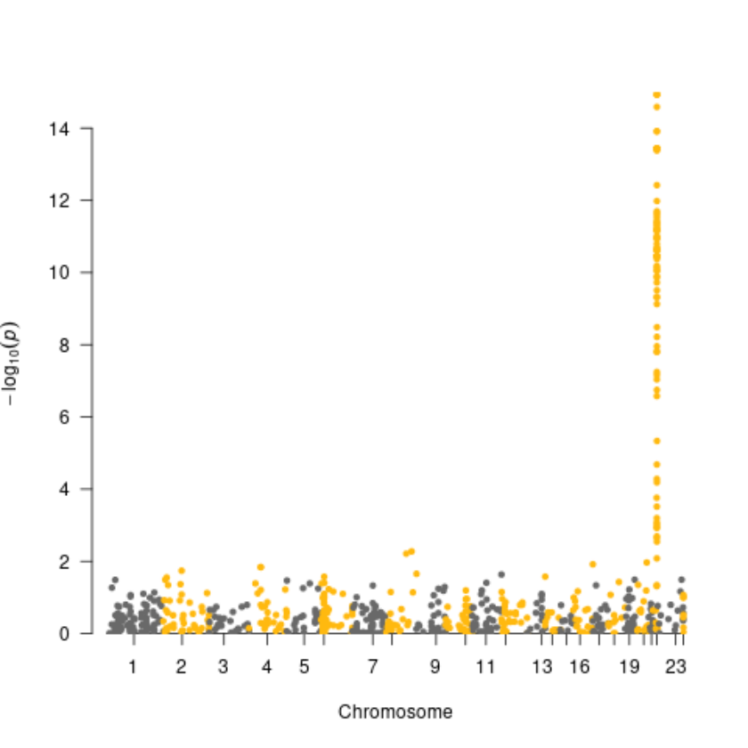

```python
# R codes- run in R
img <- readPNG("Manhattan_Plot_for_binary_z-endoxifen_ratio.png")
grid::grid.raster(img)
```

This plot is very similar compared with the Manhattan plot we got for continuous trait. They both contain a very significant SNP in chromosome 22, however, this SNP for binary trait is not so significant as for continous trait. The y-axis value for continuous trait is about 20.

## Generate Q-Q plot

Similarly, a Q-Q plot is generated with `qq` function to visualize the test results. **This code will take several minutes to finish.**

```python
# R codes- run in R
png(filename=paste0("Q-Q_Plot_for_binary_z-endoxifen_ratio.png"), type="cairo")
qq(assoc$P)
dev.off()
```

**png:** 2

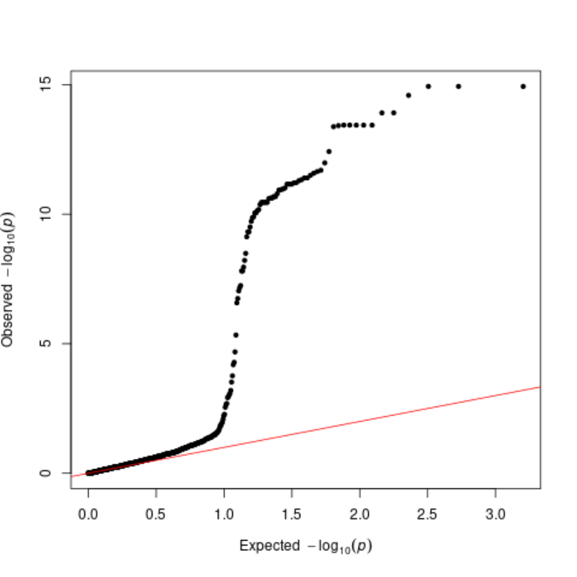

```python
# R codes- run in R
img <- readPNG("Q-Q_Plot_for_binary_z-endoxifen_ratio.png")
grid::grid.raster(img)
```

Q-Q plot still has a long tail, meaning that there are causal polymorphisms.

# Multiple-Test Correction

Again, since we simultaneously test the significance of each SNP, we need to control the overall type-I error rate using false discovery rate (FDR).

## Prepare R input files (in Linux)

The following code extracts the CHR, SNP, UNADJ, FDR_BH from the PLINK output younameit.adjusted. The results are stored in the files: **P1.assoc.adjusted**.

```python
## bash codes- run in terminal
awk '{print $1,$2,$3,$9}' younameit.P1.assoc.adjusted > P1.assoc.adjusted
```

## Significant SNPs after a multiple-test correction of FDR (using R)

The following code identifies the significant SNPs by the FDR adjusted p-values with cutoff 0.05.

```python
# R codes- run in R
assoc.adjusted=fread("P1.assoc.adjusted")#load association results
sigidx=which(assoc.adjusted$FDR_BH<0.05) #index of significant SNPs
sigSNP=assoc.adjusted[sigidx,] #extract association results for significant SNPs
write.table(sigSNP, "significant_SNPs_for_z-endoxifen_ratio.txt", row.names=F, col.names=T, quote=F, sep=" ") #save results

#view result
dim(sigSNP)
head(sigSNP)
```

1. 79

2. 4

A data.table: 6 × 4

| CHR <int> | SNP <chr> | UNADJ <dbl> | FDR_BH <dbl> |
| --- | --- | --- | --- |
| 22 | rs7245 | 1.172e-15 | 3.144e-13 |
| 22 | rs2284087 | 1.172e-15 | 3.144e-13 |
| 22 | rs5758589 | 1.172e-15 | 3.144e-13 |
| 22 | kgp7814563 | 2.593e-15 | 5.218e-13 |
| 22 | kgp11017363 | 1.228e-14 | 1.647e-12 |
| 22 | kgp137964 | 1.228e-14 | 1.647e-12 |

First we need to match genotype information such as position.

```python
# R codes- run in R
map<- fread("genotype_1k.map",header=F)
names(map) <- c("CHR","SNP","GP","BP") # assign header
zr_result <- fread("significant_SNPs_for_z-endoxifen_ratio.txt")
idx <- match(zr_result$SNP, map$SNP)#index of map that match with SNP in result
zr_result$BP <- map$BP[idx]
head(zr_result)
dim(zr_result) #get number of significant SNPs
```

A data.table: 6 × 5

| CHR <int> | SNP <chr> | UNADJ <dbl> | FDR_BH <dbl> | BP <int> |
| --- | --- | --- | --- | --- |
| 22 | rs7245 | 1.172e-15 | 3.144e-13 | 42481849 |
| 22 | rs2284087 | 1.172e-15 | 3.144e-13 | 42485671 |
| 22 | rs5758589 | 1.172e-15 | 3.144e-13 | 42518382 |
| 22 | kgp7814563 | 2.593e-15 | 5.218e-13 | 42465788 |
| 22 | kgp11017363 | 1.228e-14 | 1.647e-12 | 42348790 |
| 22 | kgp137964 | 1.228e-14 | 1.647e-12 | 42359204 |

1. 79

2. 5

Next, we will extract the SNPs with kgp identifier, and prepare the table that will be submitted to UCSC.

```python
# R codes- run in R
kgp_snps <- zr_result[grepl("kgp",zr_result$SNP),]
head(kgp_snps)
kgp_snps$CHR<- paste0("chr",kgp_snps$CHR)
kgp_snps$BP_1<- kgp_snps$BP-1
fwrite(kgp_snps[,c("CHR","BP_1","BP","SNP")], "kgp_snps.txt", sep=" ", quote=F, row.name=F, col.name=F)
```

A data.table: 6 × 5

| CHR <int> | SNP <chr> | UNADJ <dbl> | FDR_BH <dbl> | BP <int> |
| --- | --- | --- | --- | --- |
| 22 | kgp7814563 | 2.593e-15 | 5.218e-13 | 42465788 |
| 22 | kgp11017363 | 1.228e-14 | 1.647e-12 | 42348790 |
| 22 | kgp137964 | 1.228e-14 | 1.647e-12 | 42359204 |
| 22 | kgp9081934 | 3.649e-14 | 2.558e-12 | 42389839 |
| 22 | kgp12016588 | 3.649e-14 | 2.558e-12 | 42395960 |
| 22 | kgp11007658 | 3.649e-14 | 2.558e-12 | 42401749 |

After matching, we again got only 2 matched SNPs, same as in continuous study.

```python
# R codes- run in R
kgp_rs<- fread("kgp_rs.txt",header=F)
names(kgp_rs)<- c("CHR","BP_1","BP","SNP")# assign header
idx <- match(kgp_rs$BP, kgp_snps$BP)# get index of these matched SNPs in results
kgp_match<- kgp_snps[idx[!is.na(idx)],]
kgp_match$SNP<- kgp_rs$SNP[!is.na(idx)] # replace kgp identifier with rs identifier
kgp_match
```

A data.table: 2 × 6

| CHR <chr> | SNP <chr> | UNADJ <dbl> | FDR_BH <dbl> | BP <int> | BP_1 <dbl> |
| --- | --- | --- | --- | --- | --- |
| chr22 | rs60133761 | 3.508e-11 | 6.567e-10 | 42668504 | 42668503 |
| chr22 | rs140061401 | 3.649e-14 | 2.558e-12 | 42395960 | 42395959 |

```python
# R codes- run in R
rs_snps <- zr_result[grepl("rs",zr_result$SNP),]
kgp_match$CHR <- "22"
rs_snps <- rbind(rs_snps, kgp_match[,-6])
fwrite(rs_snps, "significant_snps_with_rs_for_z-endoxifen-ratio.txt", sep=" ", quote=F, row.name=F, col.name=T)
dim(rs_snps)
rs_snps
```

1. 29

2. 5

A data.table: 29 × 5

| CHR <chr> | SNP <chr> | UNADJ <dbl> | FDR_BH <dbl> | BP <int> |
| --- | --- | --- | --- | --- |
| 22 | rs7245 | 1.172e-15 | 3.144e-13 | 42481849 |
| 22 | rs2284087 | 1.172e-15 | 3.144e-13 | 42485671 |
| 22 | rs5758589 | 1.172e-15 | 3.144e-13 | 42518382 |
| 22 | rs1063392 | 3.649e-14 | 2.558e-12 | 42454950 |
| 22 | rs133335 | 3.814e-14 | 2.558e-12 | 42416056 |
| 22 | rs5751247 | 2.015e-12 | 1.014e-10 | 42633054 |
| 22 | rs8138080 | 2.271e-12 | 1.076e-10 | 42396371 |
| 22 | rs5751191 | 3.974e-12 | 1.529e-10 | 42370991 |
| 22 | rs1062753 | 3.988e-12 | 1.529e-10 | 42392811 |
| 22 | rs4467371 | 5.090e-12 | 1.782e-10 | 42541328 |
| 22 | rs932376 | 6.210e-12 | 1.993e-10 | 42614362 |
| 22 | rs2011944 | 6.932e-12 | 1.993e-10 | 42569999 |
| 22 | rs4453786 | 9.750e-12 | 2.707e-10 | 42563308 |
| 22 | rs5751255 | 1.064e-11 | 2.856e-10 | 42648408 |
| 22 | rs5751221 | 2.500e-11 | 5.296e-10 | 42516366 |
| 22 | rs5758651 | 3.508e-11 | 6.567e-10 | 42609148 |
| 22 | rs1052717 | 6.599e-11 | 1.181e-09 | 42281429 |
| 22 | rs5751239 | 1.266e-10 | 2.080e-09 | 42592239 |
| 22 | rs133280 | 4.811e-10 | 7.172e-09 | 42255525 |
| 22 | rs134871 | 3.272e-09 | 4.704e-08 | 42652716 |
| 22 | rs8140869 | 6.890e-08 | 8.946e-07 | 42344297 |
| 22 | rs742086 | 1.797e-07 | 2.260e-06 | 42552253 |
| 22 | rs5758511 | 2.643e-07 | 3.273e-06 | 42336172 |
| 22 | rs6002673 | 4.638e-06 | 5.656e-05 | 42691296 |
| 22 | rs7285782 | 5.222e-05 | 6.182e-04 | 42225018 |
| 22 | rs17365991 | 8.325e-04 | 9.180e-03 | 41790179 |
| 22 | rs9607821 | 2.249e-03 | 2.321e-02 | 41983938 |
| 22 | rs60133761 | 3.508e-11 | 6.567e-10 | 42668504 |
| 22 | rs140061401 | 3.649e-14 | 2.558e-12 | 42395960 |

## Top 10 SNPs

Here, we present the Top 10 SNPs and p-values for both binary and continuous Z-endoxifen ratio trait.

```python
# R codes- run in R
# binary trait
assoc_binary=read.table("significant_snps_with_rs_for_z-endoxifen-ratio.txt",header=T) #load association results for binary_r_met
ordered_assoc_binary=assoc_binary[order(assoc_binary$FDR_BH),] #order association results based on p-value
head(ordered_assoc_binary,10) #association results for the top 10 SNPs with the 10 smallest p-values
```

A data.frame: 10 × 5

|  | CHR <int> | SNP <chr> | UNADJ <dbl> | FDR_BH <dbl> | BP <int> |
| --- | --- | --- | --- | --- | --- |
| 1 | 22 | rs7245 | 1.172e-15 | 3.144e-13 | 42481849 |
| 2 | 22 | rs2284087 | 1.172e-15 | 3.144e-13 | 42485671 |
| 3 | 22 | rs5758589 | 1.172e-15 | 3.144e-13 | 42518382 |
| 4 | 22 | rs1063392 | 3.649e-14 | 2.558e-12 | 42454950 |
| 5 | 22 | rs133335 | 3.814e-14 | 2.558e-12 | 42416056 |
| 29 | 22 | rs140061401 | 3.649e-14 | 2.558e-12 | 42395960 |
| 6 | 22 | rs5751247 | 2.015e-12 | 1.014e-10 | 42633054 |
| 7 | 22 | rs8138080 | 2.271e-12 | 1.076e-10 | 42396371 |
| 8 | 22 | rs5751191 | 3.974e-12 | 1.529e-10 | 42370991 |
| 9 | 22 | rs1062753 | 3.988e-12 | 1.529e-10 | 42392811 |

```python
# R codes- run in R
# continuous trait
assoc_cont=read.table("../case_data/significant_snps_with_rs_for_z-endoxifen-ratio.txt",header=T) #load association results for binary_r_met
ordered_assoc_cont=assoc_cont[order(assoc_cont$FDR_BH),] #order association results based on p-value
head(ordered_assoc_cont,10) #association results for the top 10 SNPs with the 10 smallest p-values
```

A data.frame: 10 × 5

|  | CHR <int> | SNP <chr> | UNADJ <dbl> | FDR_BH <dbl> | BP <int> |
| --- | --- | --- | --- | --- | --- |
| 1 | 22 | rs8138080 | 2.683e-21 | 8.390e-19 | 42396371 |
| 2 | 22 | rs4467371 | 2.260e-20 | 3.032e-18 | 42541328 |
| 3 | 22 | rs2011944 | 6.327e-20 | 5.659e-18 | 42569999 |
| 4 | 22 | rs1062753 | 7.039e-20 | 5.666e-18 | 42392811 |
| 5 | 22 | rs4453786 | 7.743e-19 | 5.194e-17 | 42563308 |
| 6 | 22 | rs5751247 | 2.384e-18 | 1.371e-16 | 42633054 |
| 7 | 22 | rs5758651 | 3.425e-18 | 1.451e-16 | 42609148 |
| 31 | 22 | rs60133761 | 3.425e-18 | 1.451e-16 | 42668504 |
| 8 | 22 | rs5751221 | 1.307e-17 | 4.782e-16 | 42516366 |
| 9 | 22 | rs7245 | 4.272e-17 | 1.186e-15 | 42481849 |

# PRACTICE

**Compare the Top 10 SNPs for continuous and binary trait, what changes could you observe? How many common genes are identified?**